# Complemento Laboratorio Nº3

Análisis de Datos

Profesores: Ramón H. Cornejo-Muñoz y Felipe Rojas Profesor Ayudante de Laboratorio: Mauricio Vargas Ayudantes: Franco Mansilla y Mauricio Díaz Universidad Nacional Andrés Bello

## Lo que veremos

- Usar la estatura de los padres para predecir la de los hijos
- Encontrar una relación entre ambas estaturas
- Encontrar la variación de la estatura de los hijos que no depende de la estatura de los padres (variación residual)
- Los supuestos que se necesitan para generalizar más allá de los datos
- Por qué los hijos de padres muy altos tienden a ser más bajos (regresión a la media)

## Los datos de Galton

- Datos recolectados y analizados por Francis Galton en 1885.
- Galton fue un científico que creó los conceptos de correlación y regresión.
- Veremos la distribución marginal de los datos.
- La corrección por género se obtiene multiplicando la estatura de las mujeres por 1,08.

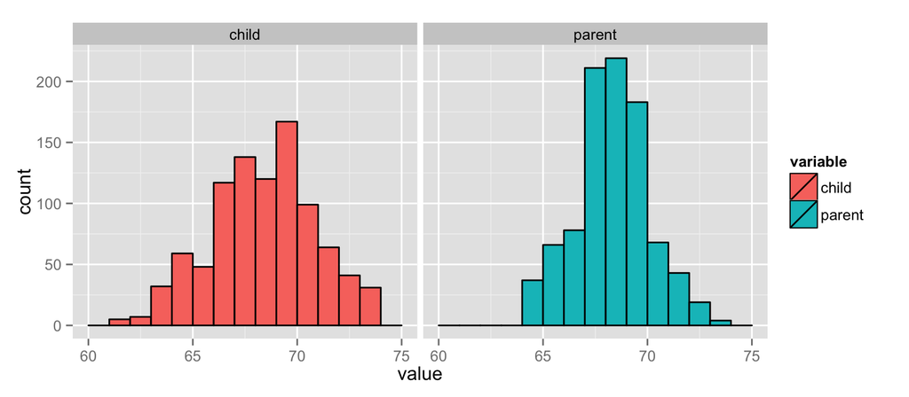

```r
library(UsingR); data(galton); library(reshape); long <- melt(galton)
g <- ggplot(long, aes(x = value, fill = variable))
g <- g + geom_histogram(colour = "black", binwidth=1)
g <- g + facet_grid(. ~ variable)
g
```

## Encontrando la media usando mínimos cuadrados

- Veamos un poco los datos

```r
head(galton, n=10) #primeras 10 observaciones (medidas en pulgadas)
```

```
   child parent
1   61.7   70.5
2   61.7   68.5
3   61.7   65.5
4   61.7   64.5
5   61.7   64.0
6   62.2   67.5
7   62.2   67.5
8   62.2   67.5
9   62.2   66.5
10  62.2   66.5
```

```r
dim(galton) #tamaño muestral = 928 ; variables  = 2
```

```
[1] 928   2
```

- Considere solo la estatura de los hijos. ¿Cómo se describe la media?
- Una definición es que siendo $Y_i$ la estatura del hijo $i$ para $i= 1,\ldots , n$ con $n=928$entonces la media es el valor de $\mu$ que minimiza la ecuación $\sum_{i=1}^n (Y_i - \mu)^2$
- Se tiene que $\mu = \bar Y$.

## Experimento

### Usar RStudio para manipular el valor de $\mu$ y observar cuál es el valor que minimiza la ecuación.

Código a replicar:

```
library(UsingR); data(galton)
library(manipulate)
myHist <- function(mu){
    mse <- mean((galton$child - mu)^2)
    g <- ggplot(galton, aes(x = child)) + geom_histogram(fill = "royalblue", colour = "black", binwidth=1)
    g <- g + geom_vline(xintercept = mu, size = 2, colour = "red")
    g <- g + ggtitle(paste("mu = ", mu, ", MSE = ", round(mse, 2), sep = ""))
    g
}
manipulate(myHist(mu), mu = slider(62, 74, step = 0.5))
```

## El estimador de mínimos cuadrados es la media empírica

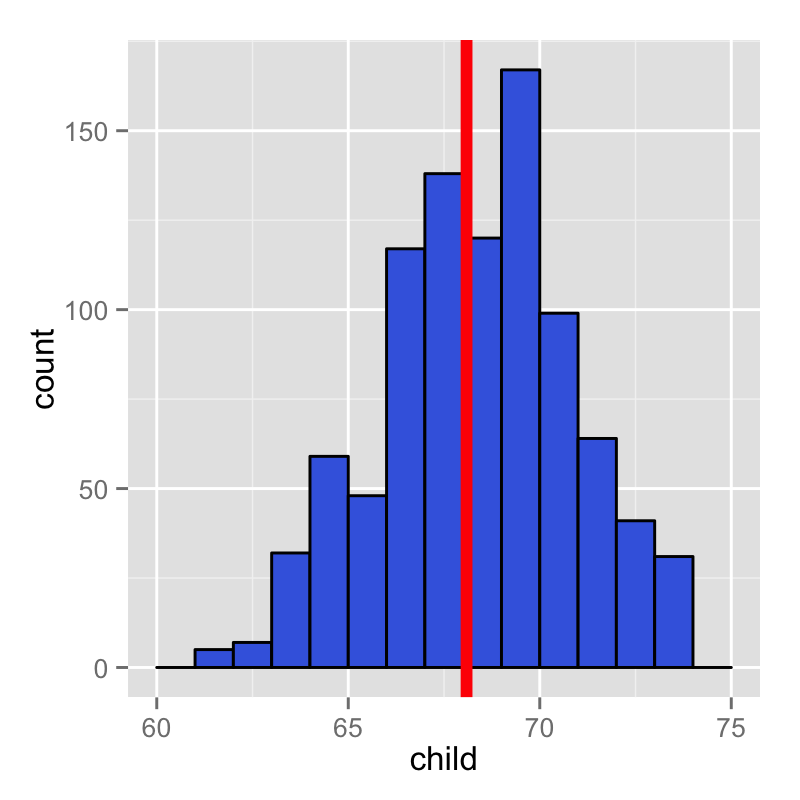

```r
g <- ggplot(galton, aes(x = child)) + geom_histogram(fill = "royalblue", colour = "black", binwidth=1)
g <- g + geom_vline(xintercept = mean(galton$child), size = 2, colour = "red")
g
```

### El desarrollo algebraico (no es parte del laboratorio como tal) es como sigue:

$\begin{align} \sum_{i=1}^n \left(Y_i - \mu\right)^2 & = \ \sum_{i=1}^n \left(Y_i - \bar Y + \bar Y - \mu\right)^2 \\ & = \sum_{i=1}^n \left(Y_i - \bar Y\right)^2 + \ 2 \sum_{i=1}^n \left(Y_i - \bar Y\right) \left(\bar Y - \mu\right) +\ \sum_{i=1}^n \left(\bar Y - \mu\right)^2 \\ & = \sum_{i=1}^n \left(Y_i - \bar Y\right)^2 + \ 2 \left(\bar Y - \mu\right) \sum_{i=1}^n \left(Y_i - \bar Y\right) +\ \sum_{i=1}^n \left(\bar Y - \mu\right)^2 \\ & = \sum_{i=1}^n \left(Y_i - \bar Y\right)^2 + \ 2 \left(\bar Y - \mu\right) \left(\left(\sum_{i=1}^n Y_i\right) -\ n \bar Y\right) +\ \sum_{i=1}^n \left(\bar Y - \mu\right)^2 \\ & = \sum_{i=1}^n \left(Y_i - \bar Y\right)^2 + \ \sum_{i=1}^n \left(\bar Y - \mu\right)^2\\ & \geq \sum_{i=1}^n \left(Y_i - \bar Y\right)^2 \ \end{align}$

## Comparando la estatura de los padres e hijos

El tamaño de los puntos en $(X,Y)$ representa la cantidad de observaciones que coinciden en dicho valor.

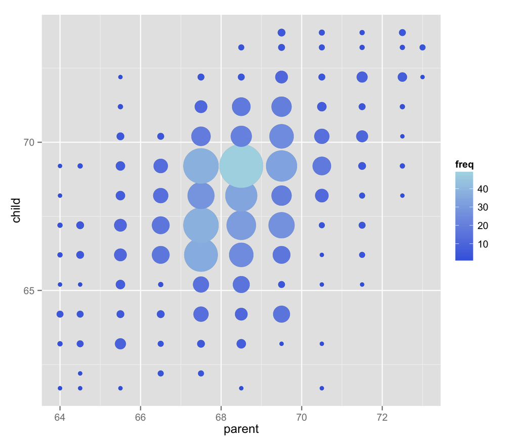

## Regresión desde el origen

- $X_i$ es la estatura de los padres.
- Se tiene un valor $\beta$ que minimiza la ecuación $\sum_{i=1}^n (Y_i - X_i \beta)^2$
- Se tiene que el intercepto es el punto $(0,0)$ y la recta es tal que minimiza la suma de las distancias verticales al cuadrado desde los puntos de cada observación a la recta.
- Para que el intercepto sea interpretable se debe restar la media de los datos de manera que el intercepto sea $(\bar{X},\bar{Y})$

## Experimento

### Usar RStudio para manipular el valor de $\beta$ y observar cuál es el valor que minimiza la ecuación.

```r
library(UsingR); data(galton)
library(dplyr)
library(manipulate)
y <- galton$child - mean(galton$child)
x <- galton$parent - mean(galton$parent)
freqData <- as.data.frame(table(x, y))
names(freqData) <- c("child", "parent", "freq")
freqData$child <- as.numeric(as.character(freqData$child))
freqData$parent <- as.numeric(as.character(freqData$parent))
myPlot <- function(beta){
  g <- ggplot(filter(freqData, freq > 0), aes(x = parent, y = child))
  g <- g  + scale_size(range = c(2, 20), guide = "none" )
  g <- g + geom_point(colour="grey50", aes(size = freq, show_guide = FALSE))
  g <- g + geom_point(aes(colour=freq, size = freq))
  g <- g + scale_colour_gradient(low = "royalblue", high="lightblue")
  g <- g + geom_abline(intercept = 0, slope = beta, size = 3)
  mse <- mean( (y - beta * x) ^2 )
  g <- g + ggtitle(paste("beta = ", beta, "mse = ", round(mse, 3)))
  g
}
manipulate(myPlot(beta), beta = slider(0, 1.2, step = 0.05))
```

## Regresión

```r
lm(I(child - mean(child)) ~ I(parent - mean(parent)) - 1, data = galton)
```

```
Call:
lm(formula = I(child - mean(child)) ~ I(parent - mean(parent)) -
    1, data = galton)

Coefficients:
I(parent - mean(parent))
                  0.6463
```

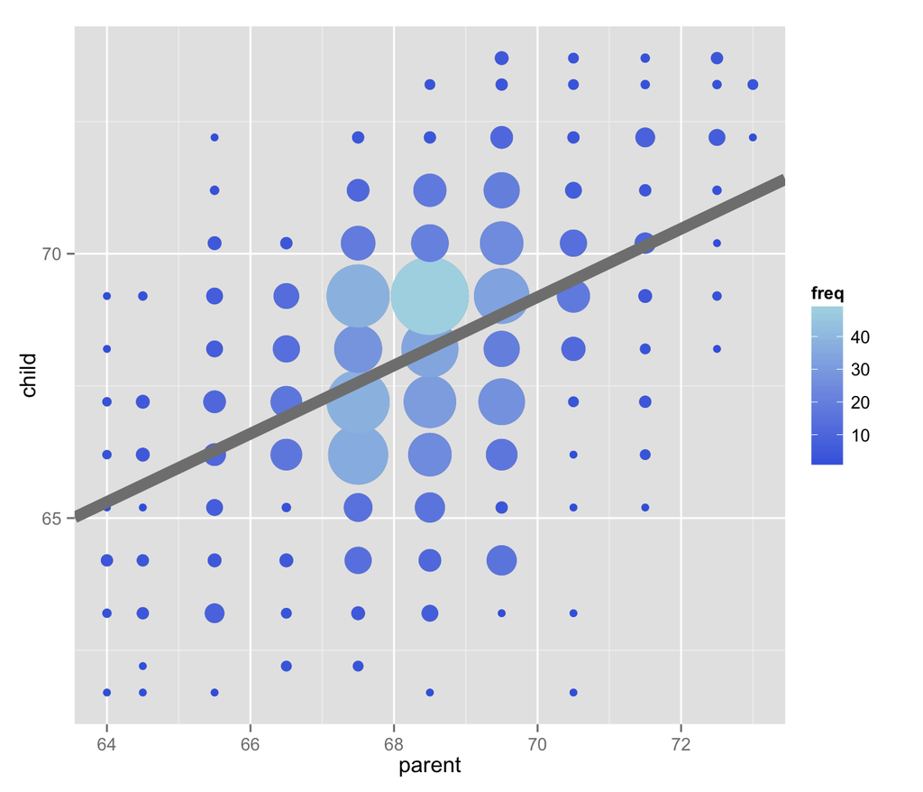